# R Notebook

Distance to green space by age group (Scotland average, 2019)

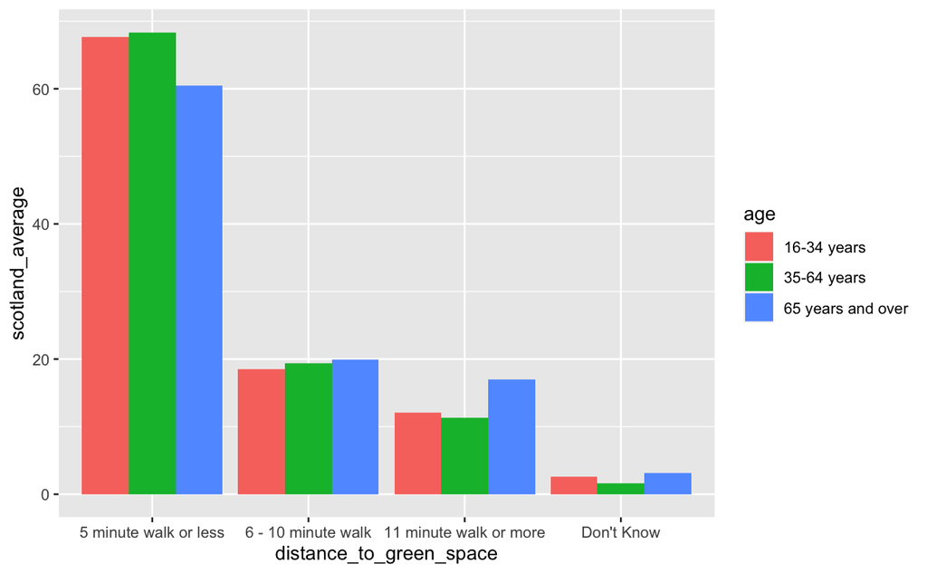

```r
green_clean %>%
  filter(age != "All" &
           date_code == 2019) %>%
  # mutate(distance_to_green_space =
  #          factor(distance_to_green_space,
  #                 levels = c("5 minute walk or less",
  #                            "6 - 10 minute walk",
  #                            "11 minute walk or more",
  #                            "Don't Know"),
  #                 ordered = TRUE)) %>%
  group_by(age, distance_to_green_space) %>%
  summarise(scotland_average = mean(value)) %>%
  ggplot(aes(x = distance_to_green_space, y = scotland_average, fill = age))+
  geom_bar(stat = "identity", position = "dodge")
```

Oldest age group has worst access to green space. Only 60% are within a five minute walk, while 17% are 11 minutes or more.

And the percentage within five minutes is trending downward over time:

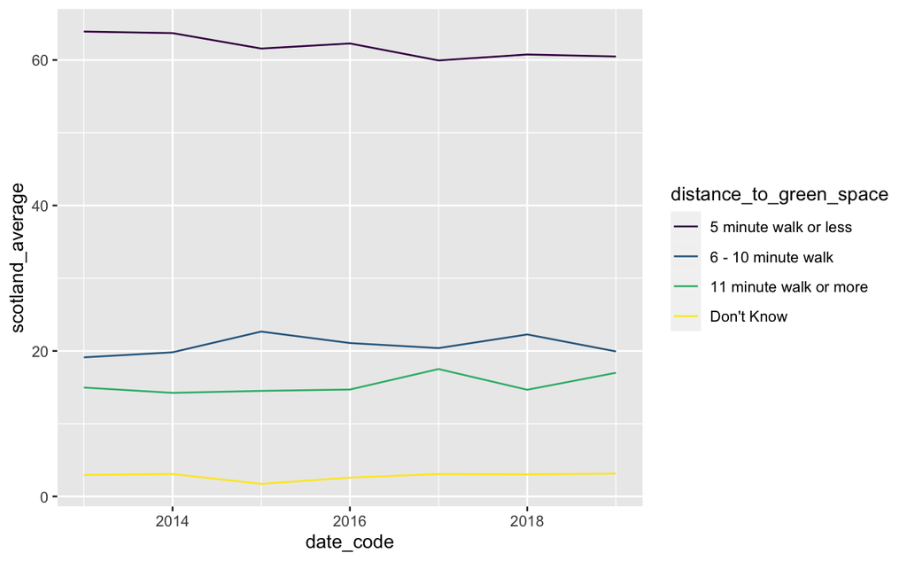

```r
green_clean %>%
  filter(age == "65 years and over") %>%
  group_by(date_code, age, distance_to_green_space) %>%
  summarise(scotland_average = mean(value)) %>%
  ggplot(aes(x = date_code, y = scotland_average, colour = distance_to_green_space))+
  geom_line()
```

URBAN RURAL CLASSIFICATION

Distance to green space by urban rural classification (Scotland average, 2019)

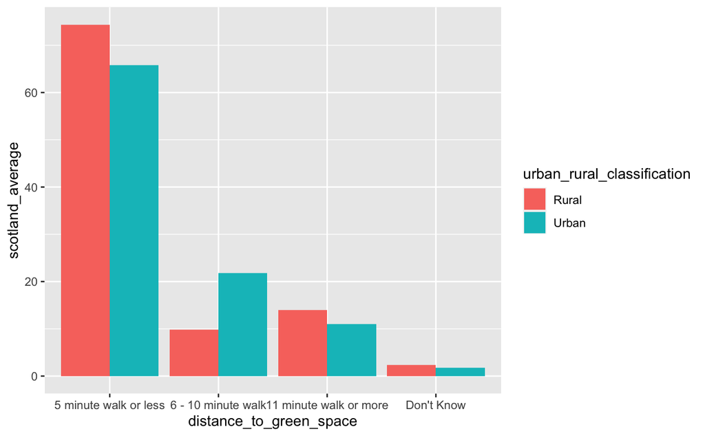

```r
green_clean %>%
  filter(urban_rural_classification != "All" &
           date_code == 2019) %>%
  group_by(urban_rural_classification, distance_to_green_space) %>%
  summarise(scotland_average = mean(value)) %>%
  ggplot(aes(x = distance_to_green_space, y = scotland_average, fill = urban_rural_classification))+
  geom_bar(stat = "identity", position = "dodge")
```

Mixed results for urban/rural. There are more people living in rural areas who are 11+ minutes from green space than there are 6-10 minutes.

Five minutes or less trending down for both rural and urban areas, far more noticeable in rural however.

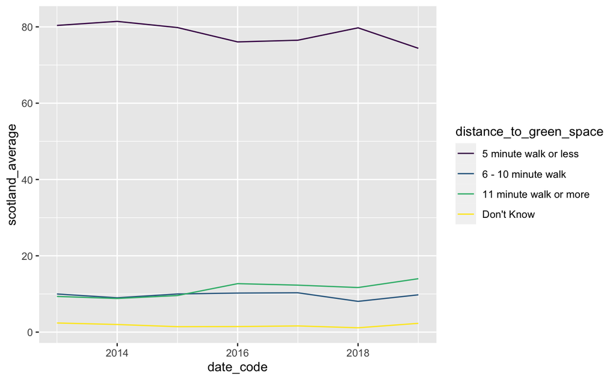

```r
green_clean %>%
  filter(urban_rural_classification == "Rural") %>%
  group_by(date_code, urban_rural_classification, distance_to_green_space) %>%
  summarise(scotland_average = mean(value)) %>%
  ggplot(aes(x = date_code, y = scotland_average, colour = distance_to_green_space))+
  geom_line()
```

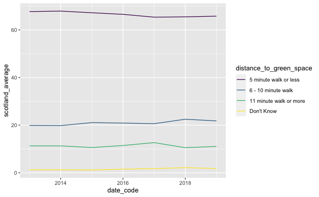

```r
green_clean %>%
  filter(urban_rural_classification == "Urban") %>%
  mutate(distance_to_green_space =
           factor(distance_to_green_space,
                  levels = c("5 minute walk or less",
                             "6 - 10 minute walk",
                             "11 minute walk or more",
                             "Don't Know"),
                  ordered = TRUE)) %>%
  group_by(date_code, urban_rural_classification, distance_to_green_space) %>%
  summarise(scotland_average = mean(value)) %>%
  ggplot(aes(x = date_code, y = scotland_average, colour = distance_to_green_space))+
  geom_line()
```

Marked difference between 20% most deprived and 80% least within five minute walk.

No meaningful trend over time for the most deprived areas.

Slight decrease in those within five minute walk for 80% least deprived.

TENURE

No significant differences between types of tenure, though social rented is lowest for five minute category.

HOUSEHOLD TYPE

Pensioners have least access to green space within five minutes, while 16.5% are more than 11 minutes away.

Percentage of pensioners within five minutes of green space has dropped from 64.7% in 2013 to 60.7% in 2019.

ETHNICITY

Very significant difference between those identifying as “White” and those who don’t.

Non-whites make up 8% of the sample size in 2019 (latest census in 2011 reported that non-whites make up 4% of the population of Scotland).

Comparatively large proportion (6%) of non-White people did not know how far their nearest green space was. This is higher than any other demographic analysed in this project.

COMMUNITY

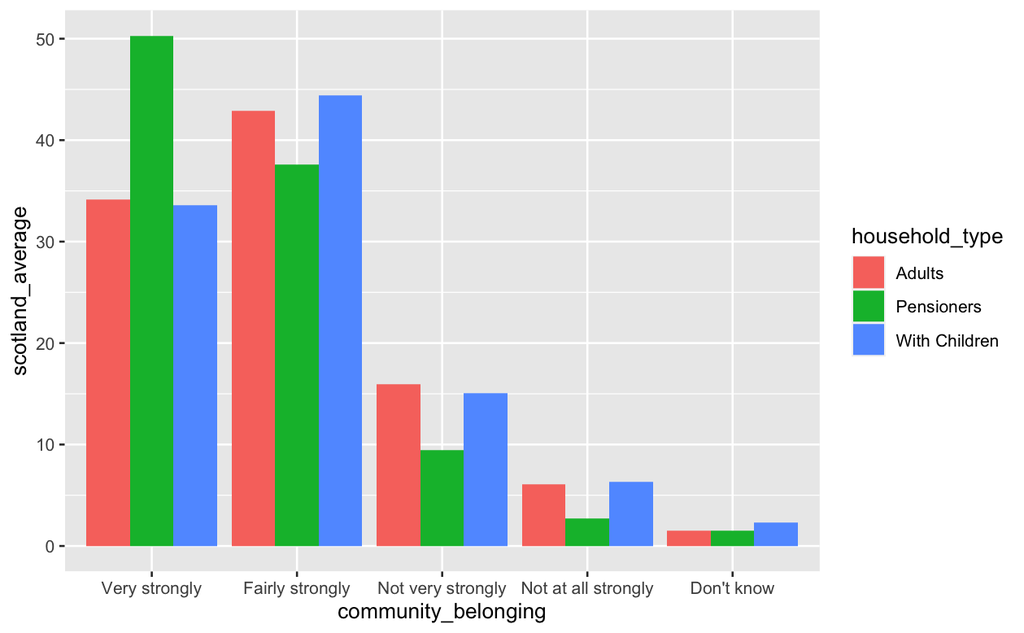

```r
community_clean %>%
  filter(household_type != "All"
         & date_code == 2019) %>%
  group_by(household_type, community_belonging) %>%
  summarise(scotland_average = mean(value)) %>%
  ggplot(aes(x = community_belonging, y = scotland_average, fill = household_type))+
  geom_bar(stat = "identity", position = "dodge")
```

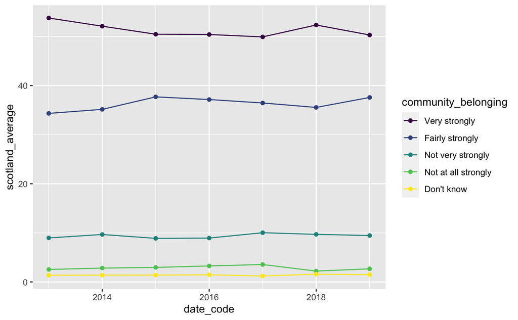

```r
community_clean %>%
  filter(household_type == "Pensioners") %>%
  group_by(date_code, household_type, community_belonging) %>%
  summarise(scotland_average = mean(value)) %>%
  ggplot(aes(x = date_code, y = scotland_average, colour = community_belonging))+
  geom_line()+
  geom_point()
```

Slight decrease over time among pensioners who feel very strongly about community belonging.

ETHNICITY

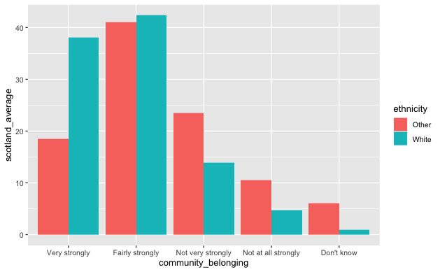

```r
community_clean %>%
  filter(ethnicity != "All"
         & date_code == 2019) %>%
  mutate(community_belonging =
           factor(community_belonging,
                  levels = c("Very strongly",
                             "Fairly strongly",
                             "Not very strongly",
                             "Not at all strongly",
                             "Don't know"),
                  ordered = TRUE)) %>%
  group_by(ethnicity, community_belonging) %>%
  summarise(scotland_average = mean(value)) %>%
  ggplot(aes(x = community_belonging, y = scotland_average, fill = ethnicity))+
  geom_bar(stat = "identity", position = "dodge")
```

Only 18.5% of non-white people stated they felt very strongly that they belong to their immediate neighbourhood, compared to 38.1% of white people.

Only 59.5% of non-white people felt very or fairly strongly, compared to 80.5% of white people.

10.5% of non-white people felt not at all strongly that they belong to their immediate neighbourhood.

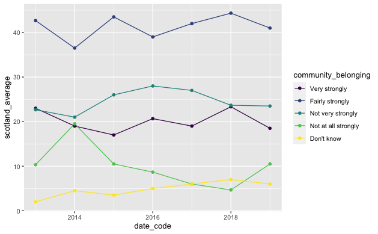

```r
community_clean %>%
  filter(ethnicity == "Other") %>%
  mutate(community_belonging =
           factor(community_belonging,
                  levels = c("Very strongly",
                             "Fairly strongly",
                             "Not very strongly",
                             "Not at all strongly",
                             "Don't know"),
                  ordered = TRUE)) %>%
  group_by(date_code, ethnicity, community_belonging) %>%
  summarise(scotland_average = mean(value)) %>%
  ggplot(aes(x = date_code, y = scotland_average, colour = community_belonging))+
  geom_line()+
  geom_point()
```

NEIGHBOURHOOD

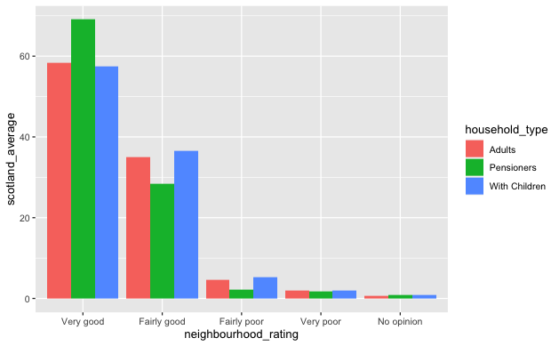

```r
neighbourhood_clean %>%
  filter(household_type != "All"
         & date_code == 2019) %>%
  group_by(household_type, neighbourhood_rating) %>%
  summarise(scotland_average = mean(value)) %>%
  ggplot(aes(x = neighbourhood_rating, y = scotland_average, fill = household_type))+
  geom_bar(stat = "identity", position = "dodge")
```

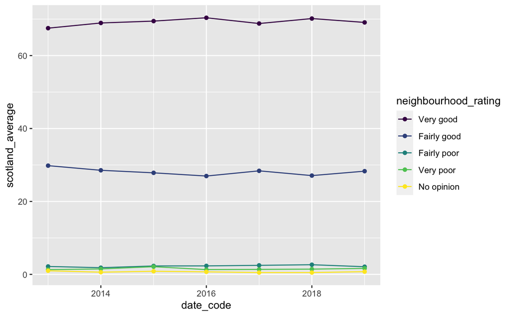

```r
neighbourhood_clean %>%
  filter(household_type == "Pensioners") %>%
  group_by(date_code, household_type, neighbourhood_rating) %>%
  summarise(scotland_average = mean(value)) %>%
  ggplot(aes(x = date_code, y = scotland_average, colour = neighbourhood_rating))+
  geom_line()+
  geom_point()
```

ETHNICITY

```r
neighbourhood_clean %>%
  filter(ethnicity != "All"
         & date_code == 2019) %>%
  group_by(ethnicity, neighbourhood_rating) %>%
  summarise(scotland_average = mean(value))
```

| ethnicity | neighbourhood_rating | scotland_average |
| --- | --- | --- |
| Other | Very good | 44.0000000 |
| Other | Fairly good | 46.0000000 |
| Other | Fairly poor | 5.5000000 |
| Other | Very poor | 3.0000000 |
| Other | No opinion | 1.5000000 |
| White | Very good | 60.9393939 |
| White | Fairly good | 33.8787879 |
| White | Fairly poor | 3.6969697 |
| White | Very poor | 1.5714286 |
| White | No opinion | 0.2105263 |

Similar picture to community_belonging; stark difference between white and other for the best rating.

Nearly twice as many non-white people rated their neighbourhood as very poor compared to white people.

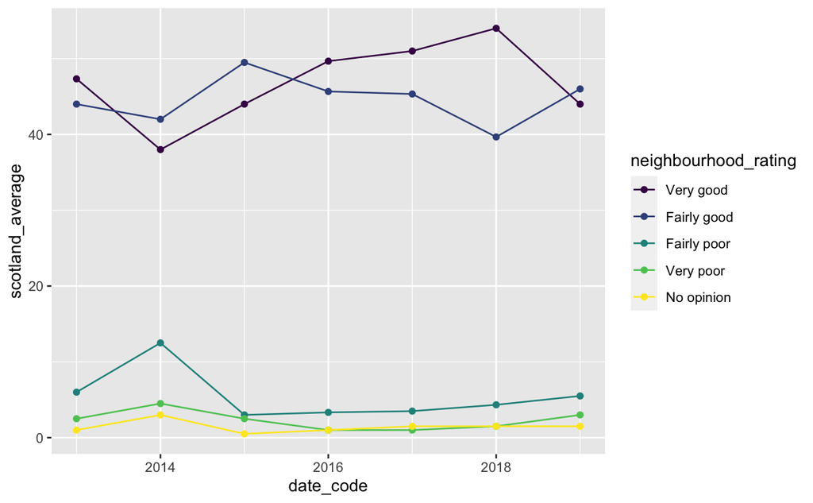

```r
neighbourhood_clean %>%
  filter(ethnicity == "Other") %>%
  group_by(date_code, ethnicity, neighbourhood_rating) %>%
  summarise(scotland_average = mean(value)) %>%
  ggplot(aes(x = date_code, y = scotland_average, colour = neighbourhood_rating))+
  geom_line()+
  geom_point()
```